# Learning Activity: Introduction to R

Tian Zheng

December 1, 2015

### A very brief introduction

- The S language was developed at AT&T Bell labs by Rick Becker, John Chambers and Allan Wilks, starting as early as in the 1970s.
- It was commercialized as S-PLUS.
- `R` is the open-source implementation of S. (google ``R programming language, wikipedia’’ to read more).
- From `R` FAQs: “Why is `R` named `R`?:

  “The name is partly based on the (first) names of the first two `R` authors (Robert Gentleman and Ross Ihaka), and partly a play on the name of the Bell Labs language `S’.”
- (IMPORTANT!!) `R` is case-sensitive.

### Getting help when using `R`

- CRAN has a number of manuals online.
- You can find help using the following `R` commands.
- `help(sort)`–using exact command names and this command needs to be loaded already. same as `\sf ?sort`.
- `` apropos(``sor'') ``–part of a command name.
- `` help.search(``sort'') ``–search the description of commands.
- `example(sort)`–show you example usage of a command.
- `` RSiteSearch(``sort'') ``–search for online available help.

### Data in `R`

- In `R`, data and functions are called `R` objects.
- Variables are stored as vectors in `R`.
- A data set is usually in the form of a matrix or array or data frame.
- Data frame can be made from vectors of the same length.
- A list is a vector of `R` data objects.
- Value assignment using `<-` or `=`.

### Basic opertaions

First let’s load some data. Type `data()` in the `Console` window will open a list of all the datasets that were included with the standard installation.

`R` uses basic syntax for simple arithmatics. In the following, the gray blocks are `R` codes you can tyep into the `console` window to try them out. The white blaocks are outputs.

```r
2+3
```

```
## [1] 5
```

```r
3^2
```

```
## [1] 9
```

```r
4/2
```

```
## [1] 2
```

```r
log(10)
```

```
## [1] 2.302585
```

```r
sin(pi/3)
```

```
## [1] 0.8660254
```

You can create a variable as a vector of data values, with each element representing the value from an individual. $X=[X_1, \ldots, X_n]$. `length()` gives you the number of entries (i.e., the sample size). `mean()` calculates the sample average of the values. Similarly, we have other founctions that compute simple statistics such as `median`, `var`, `quantile`. `table` summarizes the counts of occurances corresponding to unique values of `x`.

```r
x=c(3, 1, 4, 2, 1, 4, 5, 1,4)
length(x)
```

```
## [1] 9
```

```r
mean(x)
```

```
## [1] 2.777778
```

```r
table(x)
```

```
## x
## 1 2 3 4 5
## 3 1 1 3 1
```

### Load a R data set

Now let’s load a data set that comes with standard `R` installation: `InsectSprays`.

You can read about the documentation of this data set by typing `help(InsectSprays)` in the Console window.

```r
data(InsectSprays)
dim(InsectSprays)
```

```
## [1] 72  2
```

- The function `dim` tells us the dimension of this data set. It is a $72 \times 2$ matrix, with each row being an experiment (individual) and each column being a variable (counts of insects, types of insecticide).
- In this example, we refer to different columns of the data set by names of the column `InsectSprays[, "count"]`. We can also refer to the columns by number, `InsectSprays[,1]`.

You can summarize the values of the variable `spray` (types of insecticide) using `table` and make a pie chart using the function `pie`.

```r
table(InsectSprays[,"spray"])
```

```
##
##  A  B  C  D  E  F
## 12 12 12 12 12 12
```

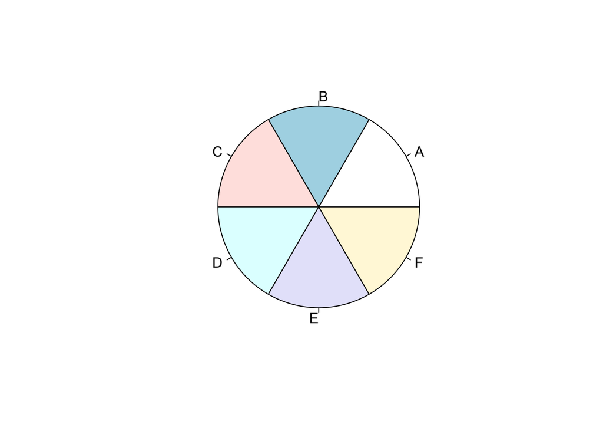

```r
pie(table(InsectSprays[,"spray"]))
```

You can summarize the values of the variable `count` (count of insects) using `summary` and visualize using `hist`.

```r
summary(InsectSprays[,"count"])
```

```
##    Min. 1st Qu.  Median    Mean 3rd Qu.    Max.
##    0.00    3.00    7.00    9.50   14.25   26.00
```

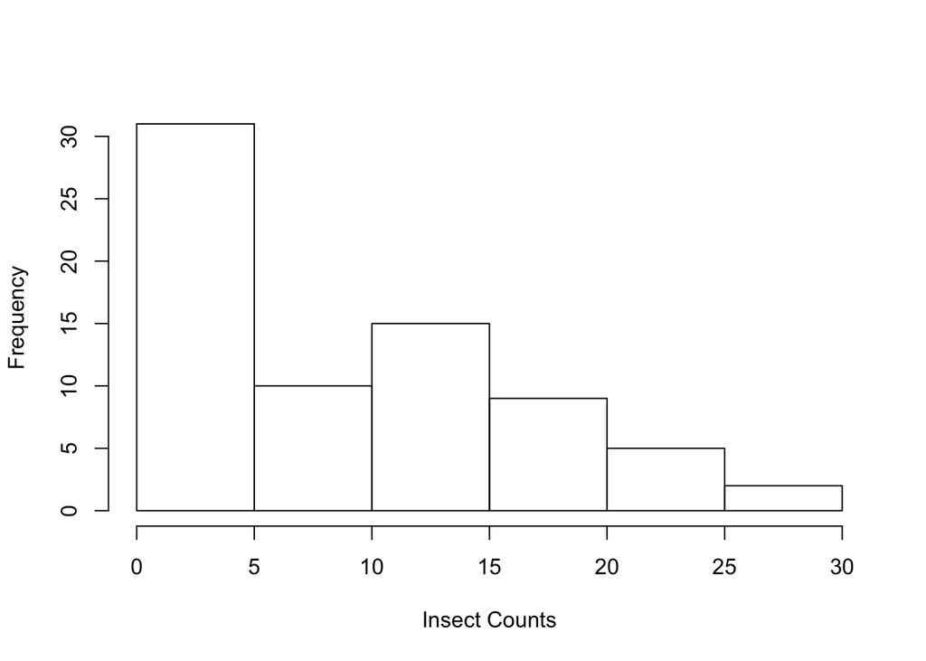

```r
hist(InsectSprays[,"count"], xlab="Insect Counts", main="")
```